# Risk Factors For Cardiovascular Heart Diseases

2023-11-30

## Risk Factors for Cadiovascular Heart diseases

Cardiovascular heart disease is a prevalent health concern, and its treatment can be costly. The various causes of cardiovascular diseases, including hereditary factors and lifestyle choices, underscore the need to identify common risk factors.

Other factors such as Mean Arterial Pressure and Body Mass Index also could be the factors for cardiovascular diseases.

## Objectives

- Does cholesterol level significantly impact the risk of cardiovascular heart disease? If yes, would an active lifestyle impact cholesterol levels?
- Is a higher BMI considered a notable risk factor for CHD?
- Can maintaining an active lifestyle reduce the risk of cardiovascular heart disease?

## Data Preparation

- Removed unnecessary variables
- Mutated columns to rename values
- Converted Age from Days to Years

```
## # A tibble: 70,000 × 13
##       id   age gender height weight ap_hi ap_lo cholesterol   gluc   smoke alco
##    <dbl> <dbl> <chr>   <dbl>  <dbl> <dbl> <dbl> <chr>         <chr>  <chr> <chr>
##  1     0    50 Female    168     62   110    80 Normal        Normal Non-… Non-…
##  2     1    55 Male      156     85   140    90 High          Normal Non-… Non-…
##  3     2    52 Male      165     64   130    70 High          Normal Non-… Non-…
##  4     3    48 Female    169     82   150   100 Normal        Normal Non-… Non-…
##  5     4    48 Male      156     56   100    60 Normal        Normal Non-… Non-…
##  6     8    60 Male      151     67   120    80 Slightly High Sligh… Non-… Non-…
##  7     9    61 Male      157     93   130    80 High          Normal Non-… Non-…
##  8    12    62 Female    178     95   130    90 High          High   Non-… Non-…
##  9    13    48 Male      158     71   110    70 Normal        Normal Non-… Non-…
## 10    14    54 Male      164     68   110    60 Normal        Normal Non-… Non-…
## # ℹ 69,990 more rows
## # ℹ 2 more variables: active <chr>, cardio <chr>
```

## Data Processing

**BMI Calculation and Labeling BMI**

- BMI = Weight/ ((height *0..01)^2)

**BMI Labels**

- 0 - 18.5) ~ “Underweight”
- 18.51 - 24.98) ~ “Normal”
- 24.98 - 29.98) ~ “Overweight”
- 29.98 - 38.8) ~ “Obese”
- 38.8 - 500) ~ “Dangerously Obese”

**MAP (Mean Arterial Pressure) Calculation and Labeling BMI**

- MAP = (ap_hi+ap_lo*2)/3

**Pressure Stat Labels**

- 0 - 90 ~ “Normal”
- 90 - 91 ~ “High BP”
- 91 - 95.99 ~ “Hypertension Stage 1”
- 96 - 150 ~ “Hypertension Stage 2”

## Blood Pressure Vs. CHD

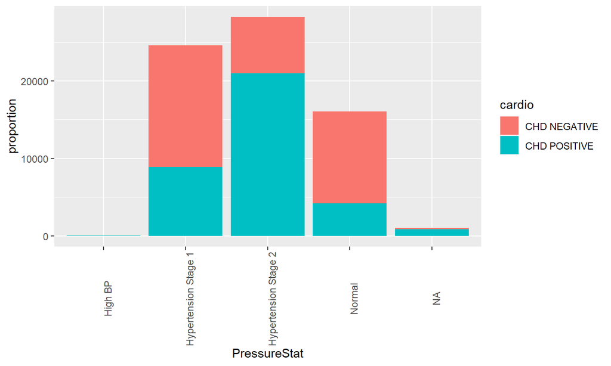

## Cleaning NA

```r
heart_data= heart_cleaned %>%
  filter(PressureStat != "NA")
```

## Bar Chart with proportion for Pressure Stat in both Genders

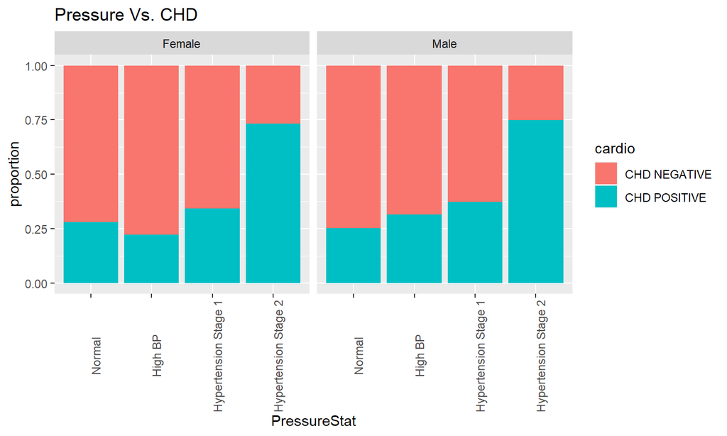

## Checking Proportion Statistics for CHD and Pressure

```r
MAPCount=table(heart_data$PressureStat,heart_data$cardio)
prop.table(MAPCount,1)
```

```
##
##                        CHD NEGATIVE CHD POSITIVE
##   Normal                  0.7384108    0.2615892
##   High BP                 0.7142857    0.2857143
##   Hypertension Stage 1    0.6377460    0.3622540
##   Hypertension Stage 2    0.2574653    0.7425347
```

Proportion of people with Normal MAP that have CHD Positive is 26%, High BP is 28%, Hypertension Stage 1 is 36% and Hypertension Stage 2 is 74%.

## Weight Vs. CHD

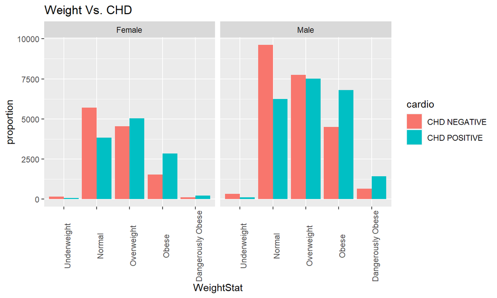

## Checking Proportion Statistics for CHD and Weight

```
##
##                     CHD NEGATIVE CHD POSITIVE
##   Underweight          0.7236025    0.2763975
##   Normal               0.6027316    0.3972684
##   Overweight           0.4947033    0.5052967
##   Obese                0.3848948    0.6151052
##   Dangerously Obese    0.3135452    0.6864548
```

27% of underweight individuals have CHD, 39% Normal, 50% Overweight, 62% Obese and 68% Dangerously obese individuals have CHD.

There is a positive association between CHD and weight, as weight increases, there is higher probablity of having CHD.

## Correlation between Age, BMI and MAP

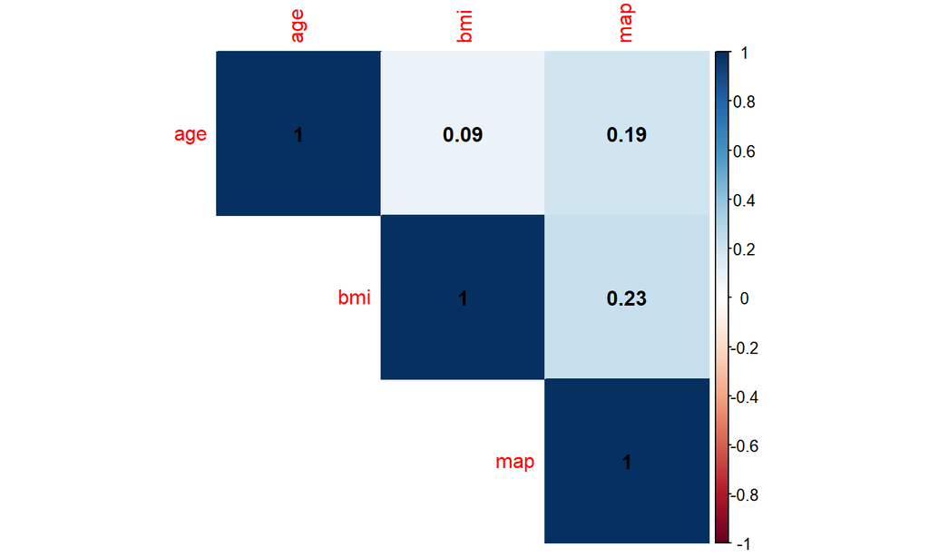

There is no strong correlation between pressure, weight and age. They have weak positive correlation between each other.

## LifeStyle Analysis

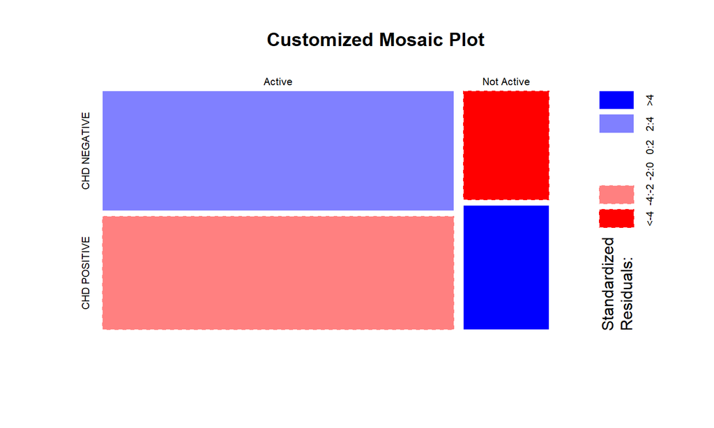

The proportion of individuals with CHD positive and non-active (who do not exercise) slightly higher. But this does not conclude the association between the two variables.

## Finding Correlation between Categorical Data with Tetrachoric Correlation

```r
library(psych)
tetrachoric(table(heart_cleaned$smoke, heart_cleaned$cardio))
```

```
## Call: tetrachoric(x = table(heart_cleaned$smoke, heart_cleaned$cardio))
## tetrachoric correlation
## [1] -0.034
##
##  with tau of
##   Non-Smoker CHD NEGATIVE
##      1.35237      0.00075
```

```r
tetrachoric(table(heart_cleaned$alco, heart_cleaned$cardio))
```

```
## Call: tetrachoric(x = table(heart_cleaned$alco, heart_cleaned$cardio))
## tetrachoric correlation
## [1] 0.019
##
##  with tau of
##      Drinker CHD NEGATIVE
##     -1.60934      0.00075
```

```r
tetrachoric(table(heart_cleaned$active, heart_cleaned$cardio))
```

```
## Call: tetrachoric(x = table(heart_cleaned$active, heart_cleaned$cardio))
## tetrachoric correlation
## [1] 0.064
##
##  with tau of
##       Active CHD NEGATIVE
##      0.85501      0.00075
```

## Finding Correlation between Categorical Data with Chisq test

Smoking status (smoke) is significantly associated with cardiovascular disease. Alcohol consumption (alco) does not show a significant association with cardiovascular disease. Physical activity (active) is highly significantly associated with cardiovascular disease.

```
##
##  Pearson's Chi-squared test with Yates' continuity correction
##
## data:  table(heart_cleaned$smoke, heart_cleaned$cardio)
## X-squared = 16.678, df = 1, p-value = 4.429e-05
```

```
##
##  Pearson's Chi-squared test with Yates' continuity correction
##
## data:  table(heart_cleaned$alco, heart_cleaned$cardio)
## X-squared = 3.6965, df = 1, p-value = 0.05453
```

```
##
##  Pearson's Chi-squared test with Yates' continuity correction
##
## data:  table(heart_cleaned$active, heart_cleaned$cardio)
## X-squared = 88.801, df = 1, p-value < 2.2e-16
```

## Cholesterol Analysis

Proportion of individuals with CHD positive increases for cholesterol normal to slightly high to high for both genders indicating there is a positive association between cholesterol and CHD.

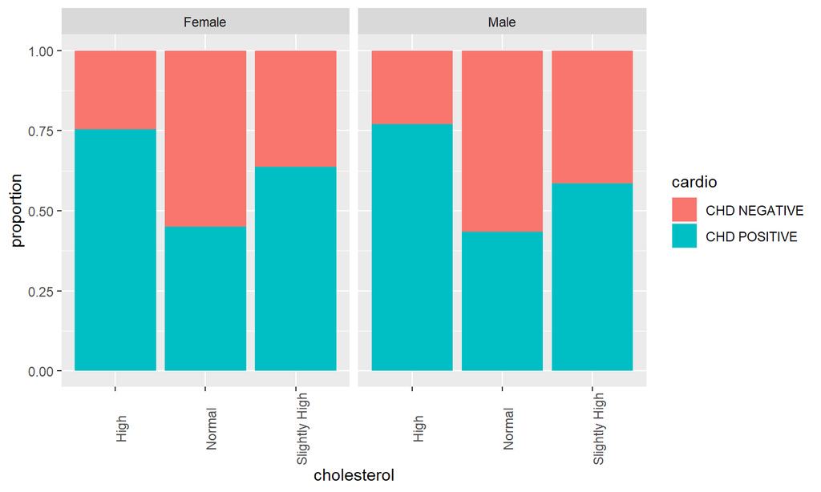

## Conclusion

Based on the exploratory data analysis in this dataset study, mean arterial pressure, weight (bmi), cholesterol has positive association with CHD. The proportion of CHD positive increased as these factors reached the higher levels.